# Lab 02 - Global plastic waste

due 9-3 at 11:59 PM

Scott Burstein

09/01/2020

# Load Packages

```r
library(tidyverse)
```

# Load Data

```r
plastic_waste <- read_csv("data/plastic-waste.csv")
```

Start by looking at the distribution of plastic waste per capita in 2010.

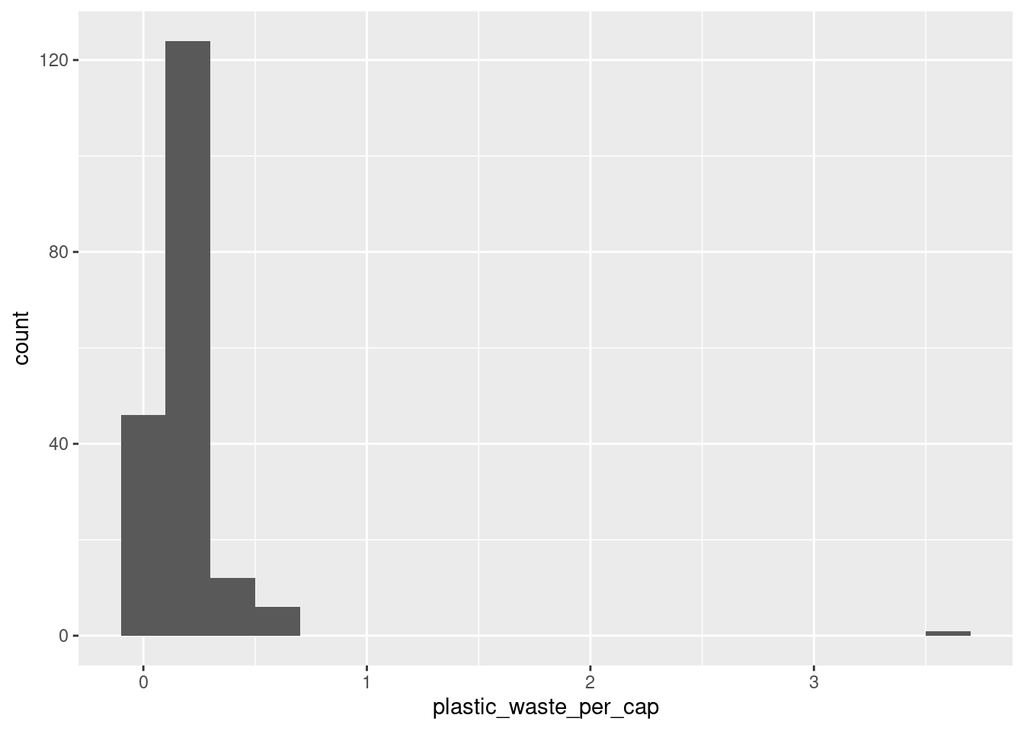

```r
ggplot(data = plastic_waste, aes(x = plastic_waste_per_cap)) +
  geom_histogram(binwidth = 0.2)
```

Identify the unusual country below.

```r
plastic_waste %>%
  filter(plastic_waste_per_cap > 3.5)
```

```
## # A tibble: 1 x 10
##   code  entity continent  year gdp_per_cap plastic_waste_p… mismanaged_plas…
##   <chr> <chr>  <chr>     <dbl>       <dbl>            <dbl>            <dbl>
## 1 TTO   Trini… North Am…  2010      31261.              3.6             0.19
## # … with 3 more variables: mismanaged_plastic_waste <dbl>, coastal_pop <dbl>,
## #   total_pop <dbl>
```

The outlying country is Trinidad and Tobago.

# Exercise 1

Plot, using histograms, the distribution of plastic waste per capita faceted by continent. What can you say about how the continents compare to each other in terms of their plastic waste per capita?

When you’re done, remember to remove the `eval = FALSE` argument.

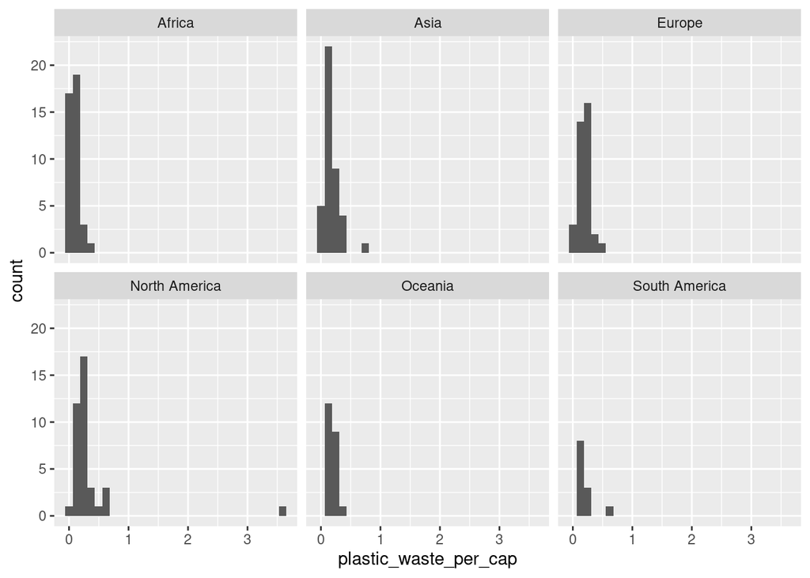

```r
ggplot(data = plastic_waste, mapping = aes(x = plastic_waste_per_cap)) +
  geom_histogram() +
  facet_wrap(~continent)
```

Regarding PWpC (Plastic Waste per Capita), a few interesting phenomena I observed in the data:

Africa is especially skewed right, indicating that on average, African countries use LESS plastic per capita than other continents, since the distribution is more tightly bunched towards a PWpC value of ~0.2.

Asia has over 20 countries that use a similar amount of PWpC, indicating that perhaps many of the Asian countries use plastics in similar ways.

For the most part, there are no drastic outliers that skew the summary statistics. Trinidad and Tobago uses by far the most plastic per capita. However, it is a very small country. A fractional change in the PWpC of larger countries like the United States or China would have far greater global implications than minimizing Trinidad and Tobago’s PWpC.

# Exercise 2

Recreate the density plots using a different (lower) alpha level that works better for displaying the density curves for all continents.

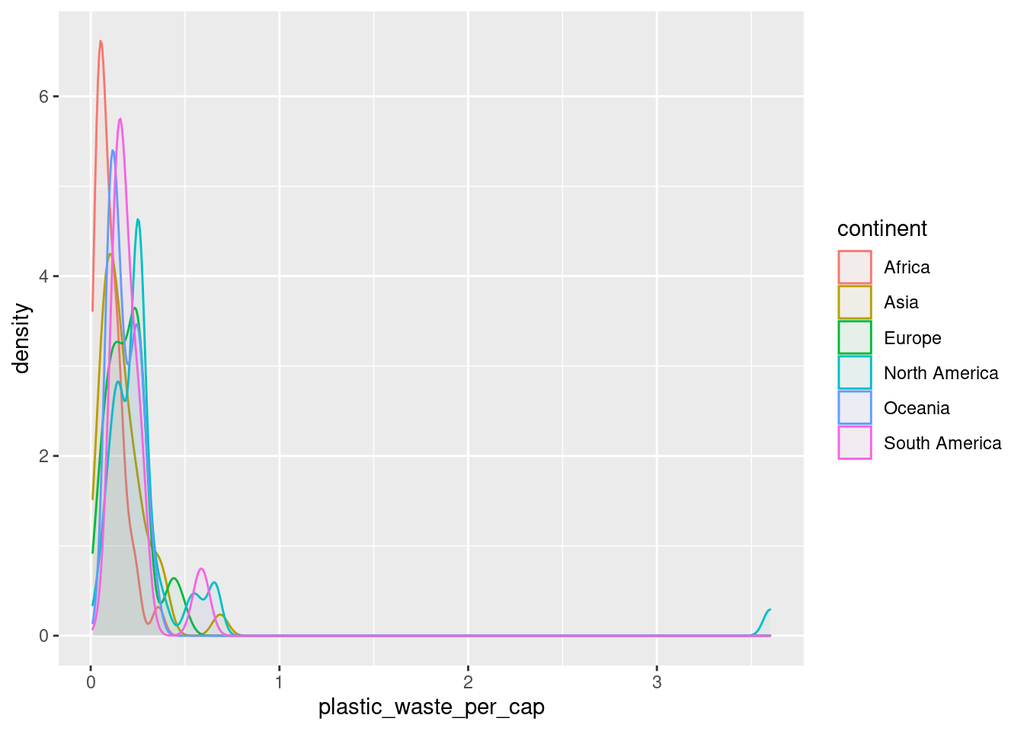

```r
ggplot(data = plastic_waste,
       mapping = aes(x = plastic_waste_per_cap,
                     color = continent,
                     fill = continent)) +
  geom_density(alpha = 0.05)
```

# Exercise 3

Describe why we defined the color and fill of the curves by mapping aesthetics of the plot but we defined the alpha level as a characteristic of the plotting geom.

Color and fill of the curves is defined by mapping aesthetics of the plot, because these are properties of the plot. Changing the color or fill would alter the way in which data is portrayed through the visual. For example, one could change the color or fill of a specific continent to highlight certain information.

On the other hand, the alpha level is defined as a characteristic of the plotting geom because it only a characteristic of the plotted geometries - in this case the density curve. Changing the alpha level has no impact on the portrayal of relative densities or the plot axes. Rather, it changes the characteristic of all geoms in the same manner.

# Exercise 4

Learn something new: violin plots! Read about them at http://ggplot2.tidyverse.org/reference/geom_violin.html, and convert your side-by-side box plots from the previous task to violin plots. What do the violin plots reveal that box plots do not? What features are apparent in the box plots but not in the violin plots?

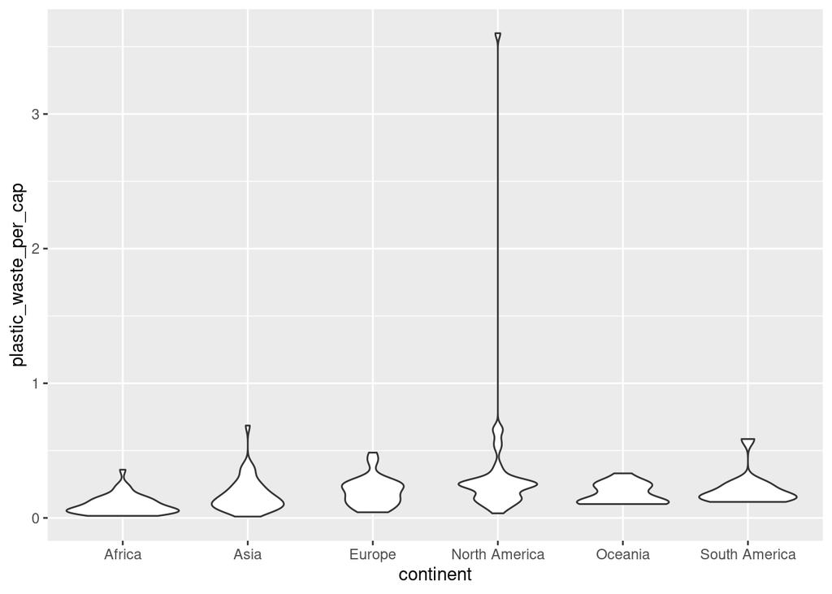

```r
ggplot(data = plastic_waste,
       mapping = aes(x = continent,
                     y = plastic_waste_per_cap)) +
  #geom_boxplot()
  geom_violin()
```

The violin plots shows in more detail the distribution and relative frequencies of different values. For example, if one of the continents has especially skewed plastic_waste_per_cap values.

The box plots are helpful for comparing Q1, median, and Q3 values.

# Exercise 5

Visualize the relationship between plastic waste per capita and mismanaged plastic waste per capita using a scatterplot. Describe the relationship.

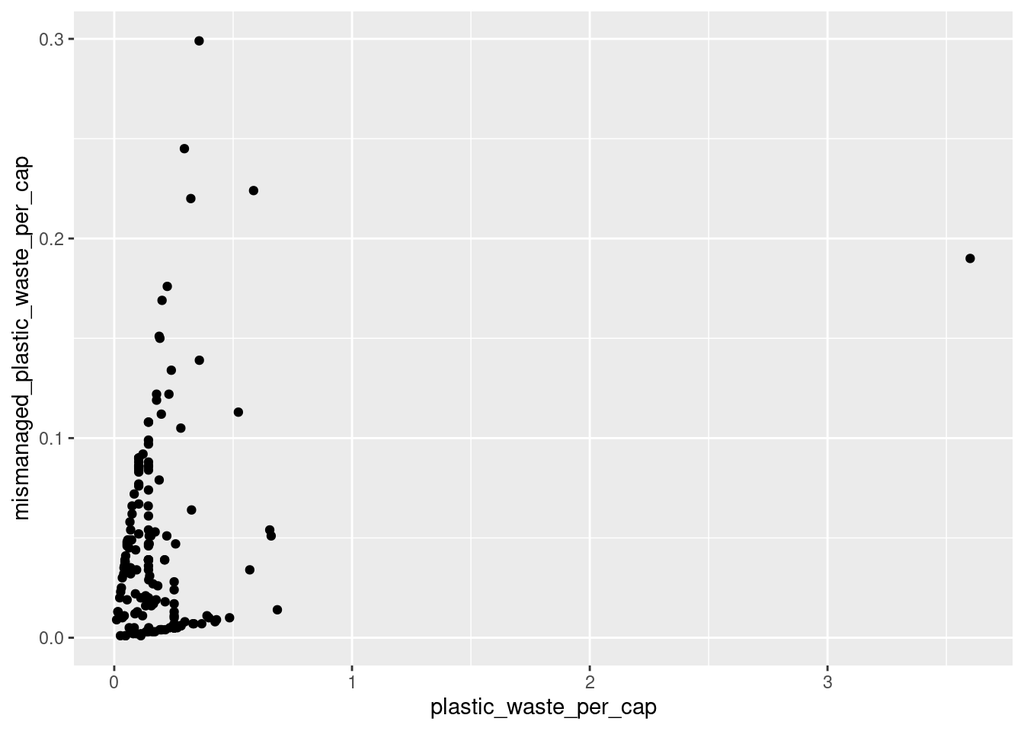

```r
ggplot(data = plastic_waste,
       mapping = aes(x = plastic_waste_per_cap,
                     y = mismanaged_plastic_waste_per_cap)) +
  geom_point()
```

There is a positive correlation between plastic waste per capita and mismanaged plastic waste per capita. However, there is definitely a large distribution of the ratio between mismanaged_plastic_waste_per_cap and plastic_waste_per_cap. There is no one clear “trend” which summarizes the data at large. Further analysis is definitely necessary.

# Exercise 6

Color the points in the scatterplot by continent. Does there seem to be any clear distinctions between continents with respect to how plastic waste per capita and mismanaged plastic waste per capita are associated?

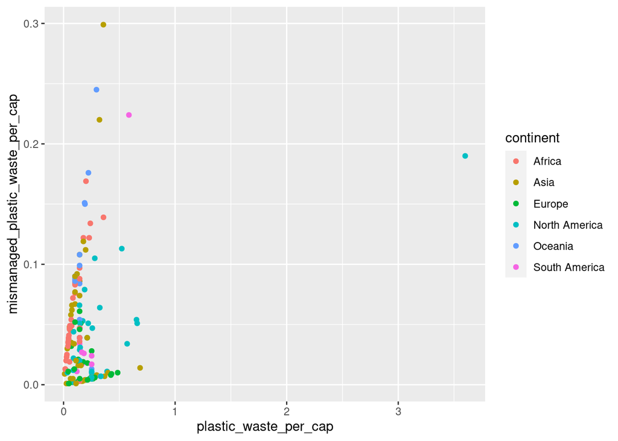

```r
ggplot(data = plastic_waste,
       mapping = aes(x = plastic_waste_per_cap,
                     y = mismanaged_plastic_waste_per_cap,
                     color = continent)) +
  geom_point()
```

Yes! There are evident distinctions between how continents deal with plastic waste per capita and mismanaged plastic waste per capita.

The “slope” of mismanaged_plastic_waste_per_cap versus plastic_waste_per_cap amongst countries in different continents varies, which correlates with a difference in the continent’s relationship with plastic waste and represents differences in initiative to minimize the mismanagement of plastic waste.

For example, European countries (represented by green geom points), have a far lower ratio of mismanaged waste / total waste, as opposed to other continents - like Africa - which has countries that have much higher mismanaged / total waste ratios.

It is important to note that this metric is not directly correlated with plastic_waste_per_capita, but rather represents the different sentiments in different continents. Effectively, it shows which continents have allocated more resources to properly managing the plastic waste they produce.

# Exercise 7

Visualize the relationship between plastic waste per capita and total population as well as plastic waste per capita and coastal population. Do either of these pairs of variables appear to be more strongly associated?

The previous exercises all provided code chunks, but for this exercise, you will need to make your own.

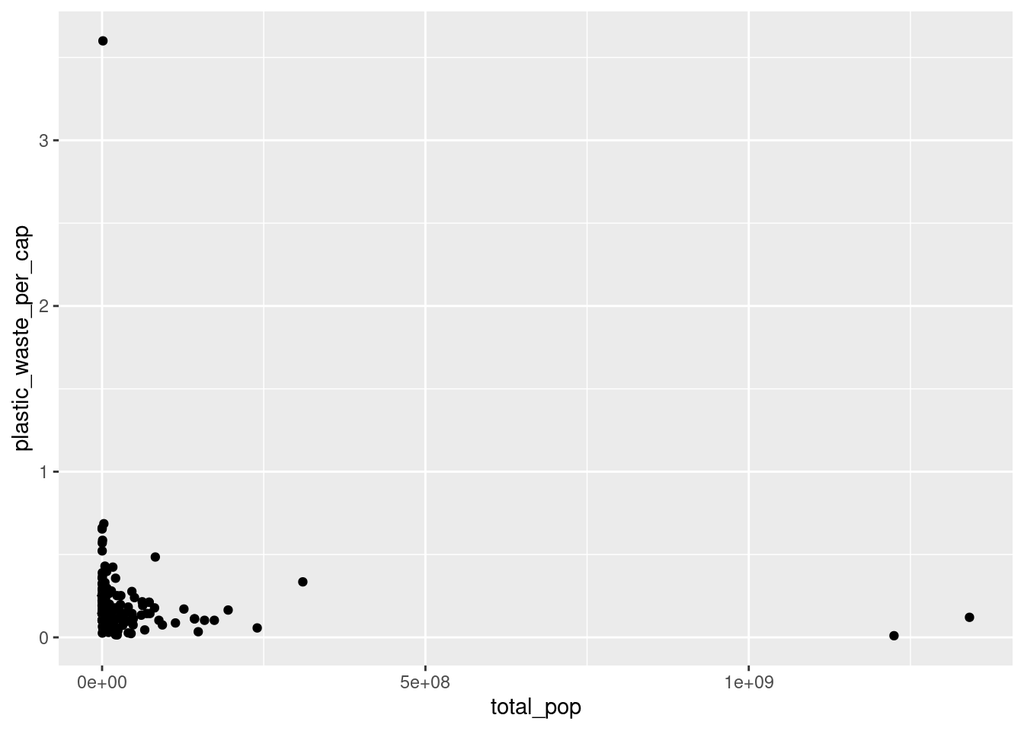

```r
ggplot(data = plastic_waste,
       mapping = aes(x = total_pop,
                     y = plastic_waste_per_cap)) +
  geom_point()
```

I decided to plot populations along the x-axis and plastic_waste_per_cap on the y-axis, since population statistics are independent of PWpC, whereas the impact of total and coastal populations on PWpC in a given country is yet to be fully understood.

The data points in the PWpC / total population visual are mostly tightly bunched with a few outliers along the x (total_pop) axis.

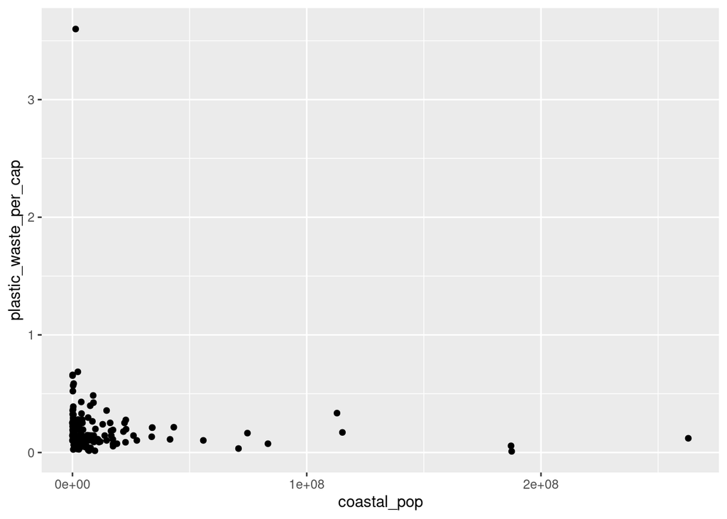

```r
ggplot(data = plastic_waste,
       mapping = aes(x = coastal_pop,
                     y = plastic_waste_per_cap)) +
  geom_point()
```

The data points in the PWpC / coastal population visual are less bunched together, with more variation amongst coastal_populations.

There are some countries that have relatively high coastal populations. The distribution would indicate that countries with high coastal populations do a better job at minimizing plastic waste, since there is zero if not a negative correlation between coastal population and plastic waste per capita.

Perhaps countries are more easily able to scale defensive measures against plastic pollution with the greater infrastructure and resources associated with larger coastal_populations. Hence necessity must lead to action.

# Exercise 8

Recreate the plot shown in the assignment, and interpret what you see in context of the data. Use the code below to filter out a country with plastic waste per capita over 3 kg/per day.

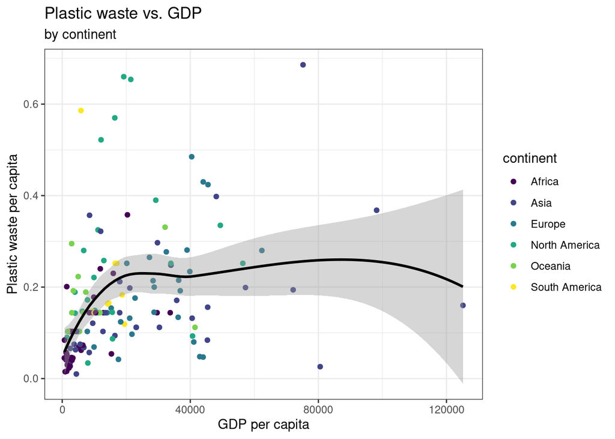

```r
plastic_waste <- plastic_waste %>%
  filter(plastic_waste_per_cap < 3)

ggplot(data = plastic_waste,
         mapping = aes(x = gdp_per_cap,
                       y = plastic_waste_per_cap,
                       color = continent)
                       ) +

                       labs(title = "Plastic waste vs. GDP",
                            subtitle = "by continent",
                            x = "GDP per capita",
                            y = "Plastic waste per capita") +

    geom_point() +
    scale_colour_viridis_d() +
    theme_bw() +

    geom_smooth(data = plastic_waste,
                mapping = aes(x = gdp_per_cap,
                              y = plastic_waste_per_cap,
                              color = NULL),
                color = "black")
```

Based on this data and visualization, there appears to be a moderately strong positive correlation between GDP and plastic waste per capita for countries with GDP per capita < 20000 (USD? presumably).

For countries with GDP > ~25000, the correlation is less clear. The geom_smooth() trend line flattens out, indicating no explicit correlation between an increase in GDP and change in Plastic waste per capita. Further proof of this is that the geom_smooth() error range (light gray range) widens at larger GDP per capita values. The countries with larger GDP per capita have more scattered Plastic waster per capita values.